# Multi-Reference Indicator Comparison: VA Respiratory: Rsv Cases/100k (7dav)

Author

Delphi Group

Published

September 1, 2026

This report evaluates one **candidate indicator** against multiple **reference indicators**. Each diagnostic is computed pairwise; references are not combined.

| Role | Source | Indicator | Label |
| --- | --- | --- | --- |
| Candidate | csv | rsv_rate_state | VA Respiratory: Rsv Cases/100k (7dav) |
| Reference | csv | rsv_ref_claims_outpatient_state | Outpatient Claims: % ARI, non-COVID/flu (daily) |
| Reference | csv | rsv_ref_nssp_state | NSSP: Smoothed % ED Visits, RSV (wk-&gt;day interp.) |

## 1 Exploratory Data Analysis

This section checks overlap, scale, missingness, and variation for each candidate/reference pair.

### 1.1 Data Sources and Pairwise Overlap

The candidate and references are loaded once, then paired by panel and time. A panel is one location plus any configured extra key columns. Dashed vertical lines mark the requested analysis window; overlap values are pairwise with the candidate.

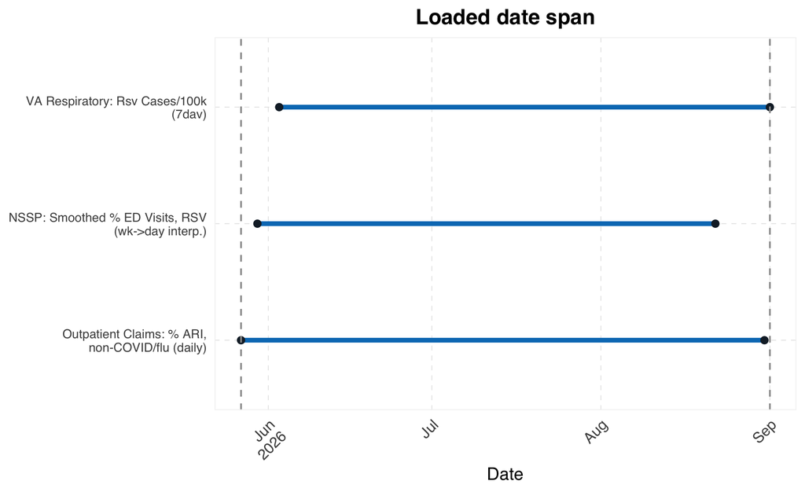

Loaded data volume and candidate/reference overlap.

| Role | Indicator | Rows loaded | Panels loaded | Locations loaded | Dates loaded | First date | Last date | Overlap rows | Overlap locations | Overlap dates | Overlap percent |
| --- | --- | --- | --- | --- | --- | --- | --- | --- | --- | --- | --- |
| Candidate | VA Respiratory: Rsv Cases/100k (7dav) | 4,550 | 50 | 50 | 91 | 2026-06-03 | 2026-09-01 | Not applicable | Not applicable | Not applicable | Not applicable |
| Reference | NSSP: Smoothed % ED Visits, RSV (wk->day interp.) | 4,321 | 51 | 51 | 85 | 2026-05-30 | 2026-08-22 | 3,955 | 49 | 81 | 77.6% |
| Reference | Outpatient Claims: % ARI, non-COVID/flu (daily) | 4,947 | 51 | 51 | 97 | 2026-05-27 | 2026-08-31 | 4,410 | 49 | 90 | 86.5% |

### 1.2 Time Series Overview

Each indicator is standardized within panel; the plot shows the median standardized value across panels at each date. A panel is one location plus any configured extra key columns. This overview uses the loaded data for each indicator and is not recomputed separately for each candidate/reference pair.

For each indicator and location, values are standardized as

$$Z_{g,t}=\frac{X_{g,t}-\bar{X}_g}{s_g},$$

where $X_{g,t}$ is the raw value, $\bar{X}_g$ is the panel mean, and $s_g$ is the panel standard deviation.

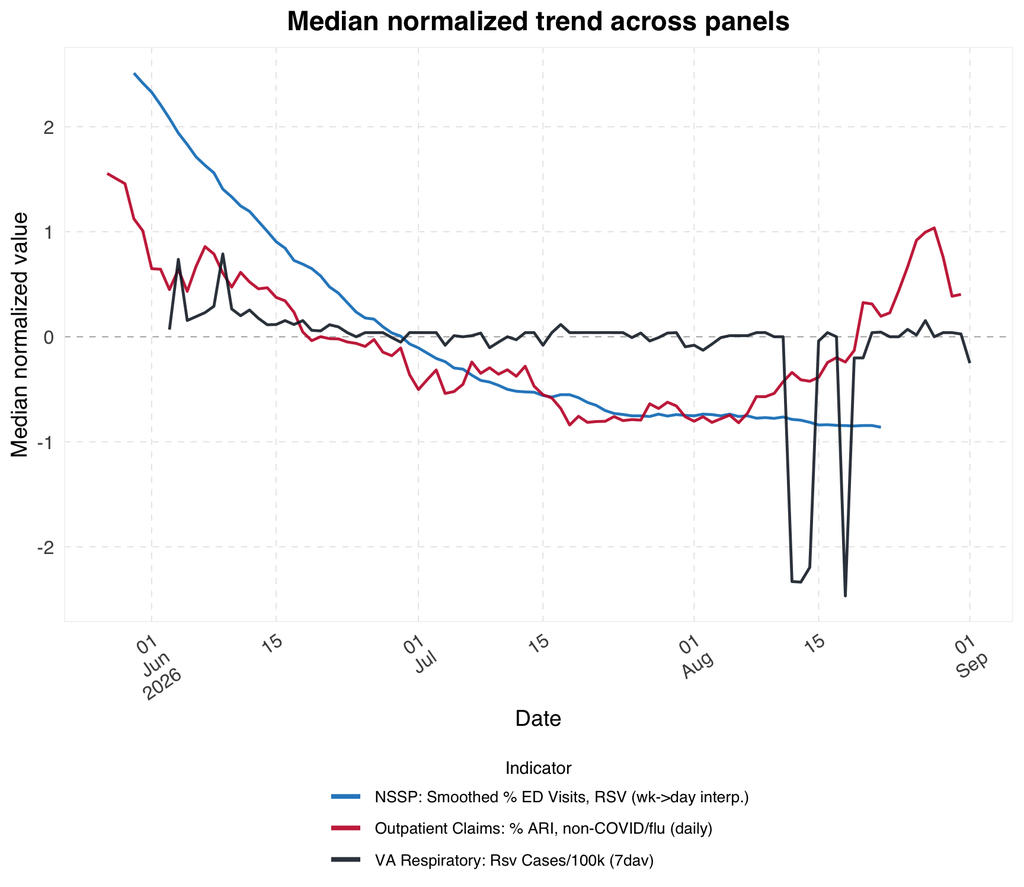

### 1.3 Quantile Trends

This plot shows cross-panel quantiles after within-panel standardization. A panel is one location plus any configured extra key columns. Candidate quantiles are recomputed on each candidate/reference overlap.

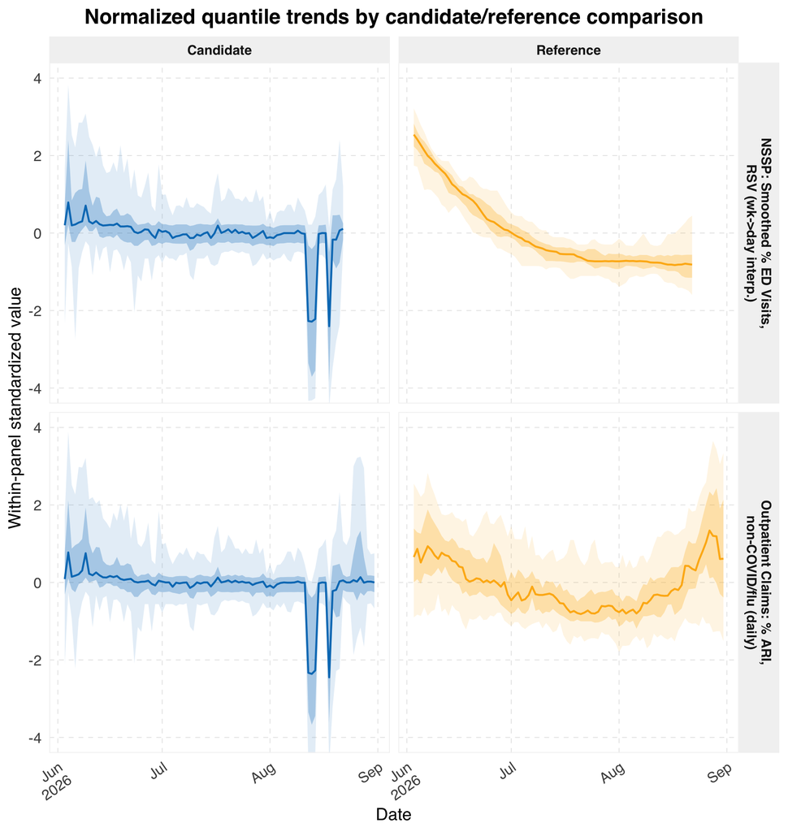

### 1.4 Coverage and Missingness

This plot shows candidate, reference, and pairwise-overlap location counts by date. “Both” is the sample size for date-specific spatial correlations.

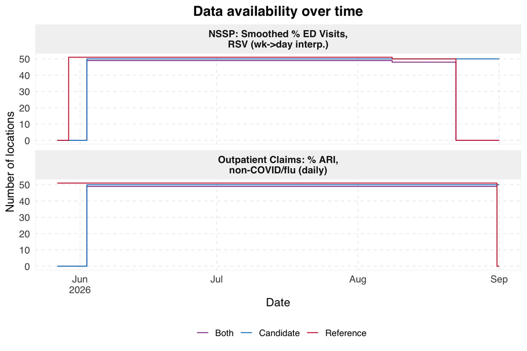

### 1.5 Summary Statistics and Missingness

This section summarizes values and missingness by panel. A panel is one location plus any configured extra key columns. Because Epidata sources usually omit unavailable rows rather than returning explicit missing values, missingness is computed after expanding each candidate/reference pair to the union of candidate and reference panels over the requested time grid.

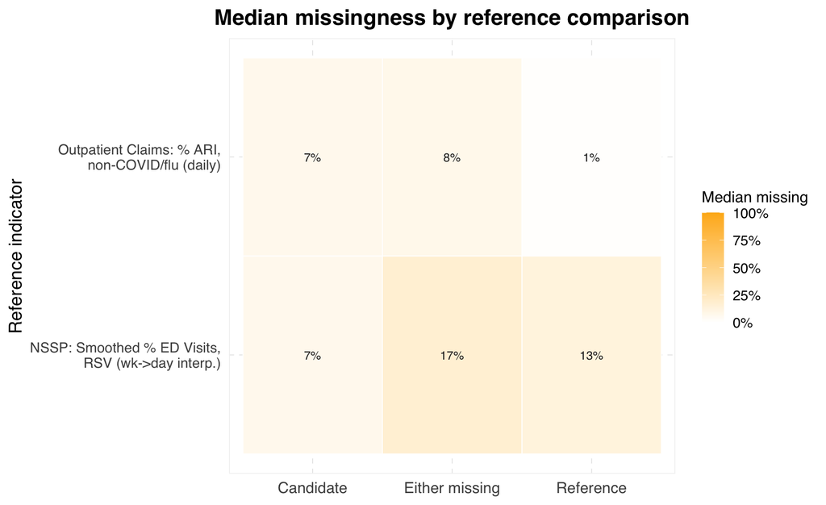

| Reference | Geo value | Geo name | Periods | Candidate mean | Candidate missing | Reference mean | Reference missing | Either missing |
| --- | --- | --- | --- | --- | --- | --- | --- | --- |
| NSSP: Smoothed % ED Visits, RSV (wk-&gt;day interp.) | ak | Alaska | 98 |  | 100.0% | 0.03835294093279278 | 13.3% | 100.0% |
| NSSP: Smoothed % ED Visits, RSV (wk-&gt;day interp.) | hi | Hawaii | 98 |  | 100.0% | 0.1424705871764351 | 13.3% | 100.0% |
| NSSP: Smoothed % ED Visits, RSV (wk-&gt;day interp.) | pr | Puerto Rico Commonwealth | 98 | 0.1224874019558187 | 7.1% |  | 100.0% | 100.0% |
| Outpatient Claims: % ARI, non-COVID/flu (daily) | ak | Alaska | 98 |  | 100.0% | 0.0487433064168939 | 1.0% | 100.0% |
| Outpatient Claims: % ARI, non-COVID/flu (daily) | hi | Hawaii | 98 |  | 100.0% | 0.08096487131412272 | 1.0% | 100.0% |
| Outpatient Claims: % ARI, non-COVID/flu (daily) | pr | Puerto Rico Commonwealth | 98 | 0.1224874019558187 | 7.1% |  | 100.0% | 100.0% |
| NSSP: Smoothed % ED Visits, RSV (wk-&gt;day interp.) | ia | Iowa | 98 | -0.003935375440357194 | 7.1% | 0 | 27.6% | 31.6% |
| NSSP: Smoothed % ED Visits, RSV (wk-&gt;day interp.) | al | Alabama | 98 | 0.04396606697247235 | 7.1% | 0.07611764643122168 | 13.3% | 17.3% |
| NSSP: Smoothed % ED Visits, RSV (wk-&gt;day interp.) | ar | Arkansas | 98 | 0.02572617113077462 | 7.1% | 0.05399999947232358 | 13.3% | 17.3% |
| NSSP: Smoothed % ED Visits, RSV (wk-&gt;day interp.) | az | Arizona | 98 | 0.03569032810433028 | 7.1% | 0.02435294102658244 | 13.3% | 17.3% |

[output cut: 94 more lines]

### 1.6 Noise Assessment

Coefficient of variation (CV) is `sd(value) / abs(mean(value))` within location. Negative CV difference, or points below the diagonal, means the candidate has lower relative variation than the reference.

| reference_name | Locations compared | Median candidate CV | Median reference CV | Median CV difference | % candidate smoother |
| --- | --- | --- | --- | --- | --- |
| NSSP: Smoothed % ED Visits, RSV (wk-&gt;day interp.) | 46 | 4.38004147648893 | 0.6173946066619417 | 3.717087486972485 | 0 |
| Outpatient Claims: % ARI, non-COVID/flu (daily) | 47 | 4.406796776659062 | 0.2832513336262333 | 4.015726627696456 | 0 |

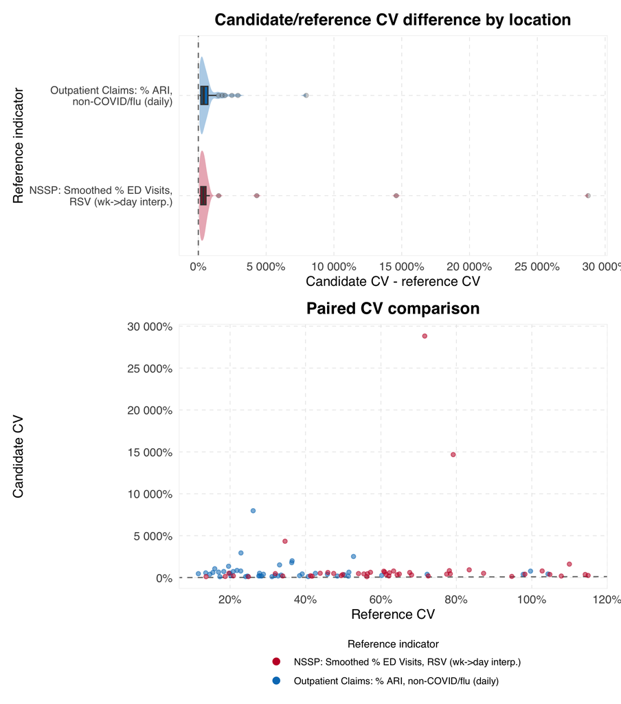

## 2 Correlation Analysis

All correlations use rows where both candidate and reference are observed. Spearman correlation ranges from -1 to 1: similar rankings, little monotone association, and opposite rankings respectively.

### 2.1 Correlation Over Locations

Let $C_{g,t}$ be the candidate value and $R^{(k)}_{g,t}$ be reference $k$ at location $g$ and time $t$. $\operatorname{cor}_S(x,y)$ is Spearman correlation after dropping missing pairs.

For each reference indicator $k$ and date $t$, the pairwise spatial correlation is computed across locations:

$$s^{(k)}_{\text{space},t}
= \operatorname{cor}_S
\left(
\{C_{g,t}\}_{g},
\{R^{(k)}_{g,t}\}_{g}
\right).$$

Faint lines are date-specific correlations; thick lines are LOESS trends.

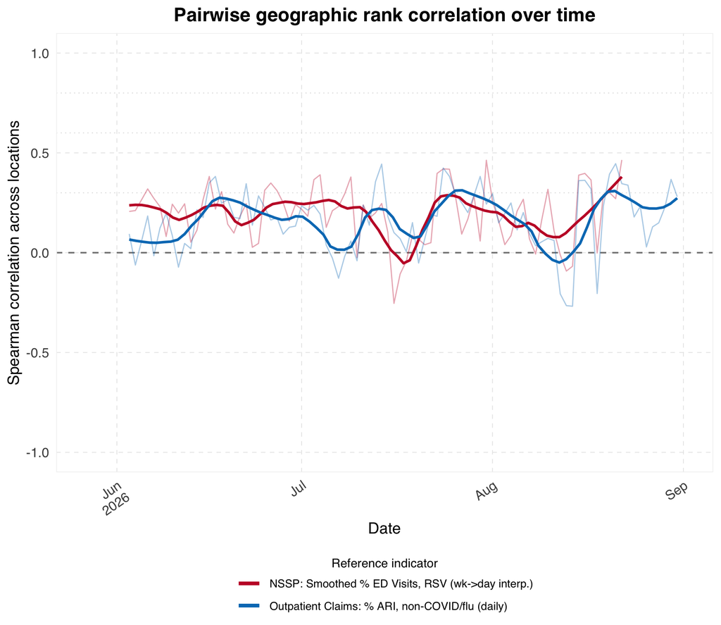

#### 2.1.1 Dates With Minimum Spatial Agreement

Dates with minimum spatial correlation for each candidate/reference pair.

Dates with minimum spatial agreement for each candidate/reference pair.

| Reference | Date | Locations compared | Spatial Spearman correlation |
| --- | --- | --- | --- |
| NSSP: Smoothed % ED Visits, RSV (wk->day interp.) | 2026-07-16 | 49 | -0.254 |
| NSSP: Smoothed % ED Visits, RSV (wk->day interp.) | 2026-07-17 | 49 | -0.107 |
| NSSP: Smoothed % ED Visits, RSV (wk->day interp.) | 2026-08-13 | 48 | -0.092 |
| NSSP: Smoothed % ED Visits, RSV (wk->day interp.) | 2026-08-14 | 48 | -0.068 |
| NSSP: Smoothed % ED Visits, RSV (wk->day interp.) | 2026-07-18 | 49 | -0.042 |
| Outpatient Claims: % ARI, non-COVID/flu (daily) | 2026-08-14 | 49 | -0.268 |
| Outpatient Claims: % ARI, non-COVID/flu (daily) | 2026-08-13 | 49 | -0.265 |
| Outpatient Claims: % ARI, non-COVID/flu (daily) | 2026-08-12 | 49 | -0.206 |
| Outpatient Claims: % ARI, non-COVID/flu (daily) | 2026-08-18 | 49 | -0.204 |
| Outpatient Claims: % ARI, non-COVID/flu (daily) | 2026-07-07 | 49 | -0.128 |

### 2.2 Correlation Over Time Within Locations

Each correlation is computed across dates within one location at zero lag. Histograms show the location-level distributions; dashed lines mark reference-specific medians.

For each reference indicator $k$ and location $g$, the pairwise temporal correlation is:

$$s^{(k)}_{\text{time},g}
= \operatorname{cor}_S
\left(
\{C_{g,t}\}_{t},
\{R^{(k)}_{g,t}\}_{t}
\right).$$

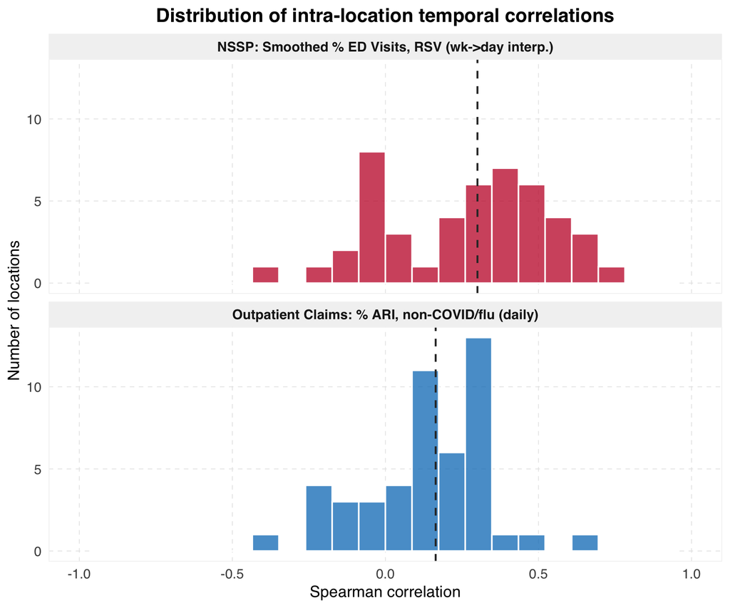

#### 2.2.1 Empirical Uncertainty

Intervals summarize empirical variation: spatial across dates, temporal across locations. Thick intervals are 25th-75th percentiles; thin intervals are 10th-90th percentiles.

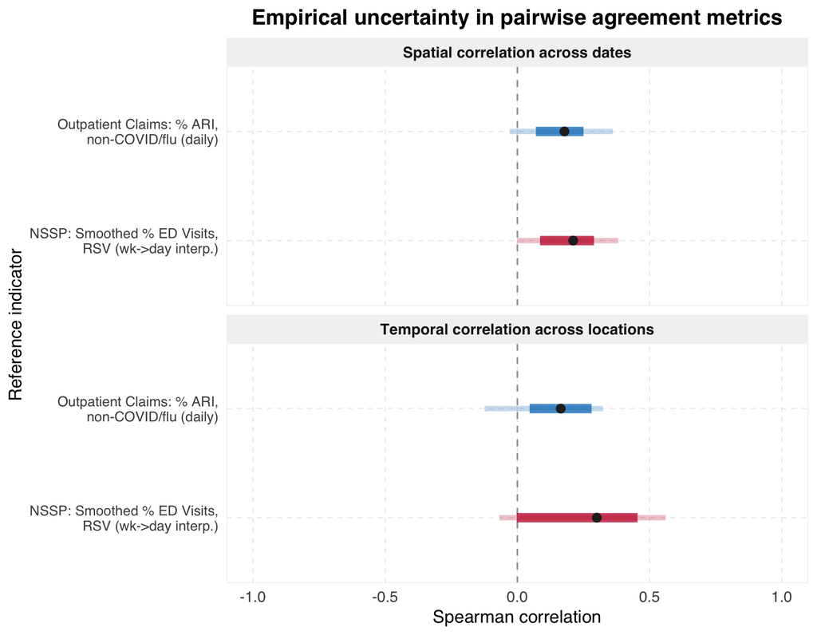

### 2.3 Lagged Correlations

Lag $\ell$ is measured in days. Positive lag compares earlier candidate values with current reference values; negative lag shifts the candidate later.

For lag $\ell$, the shifted candidate is compared with the reference:

$$C_{g,t-\ell}
\quad \text{vs.} \quad
R^{(k)}_{g,t}.$$

#### 2.3.1 Systematic Lag Analysis

Lag response curves show median within-location correlation by lag; ribbons show the 25th-75th percentile range. Matrix cells show mean correlation; white dots mark the lag with the highest mean temporal correlation for each reference.

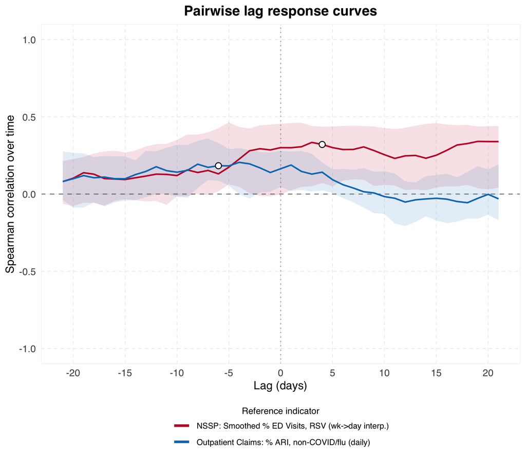

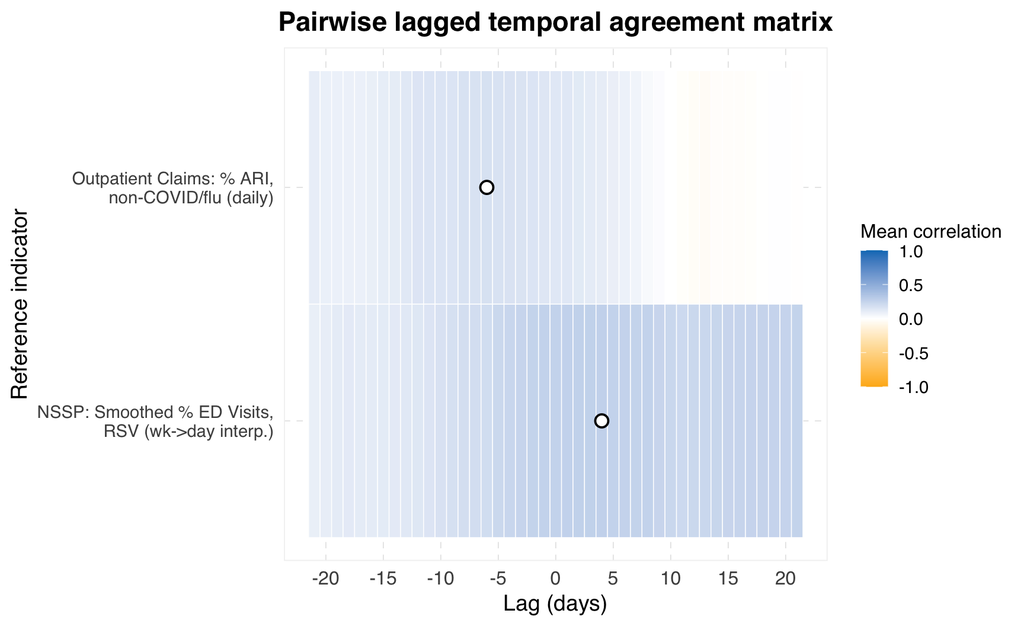

#### 2.3.2 Correlation over time, at different days

Correlations are computed across locations at each date after shifting the candidate. Each facet is one selected lag; color identifies reference.

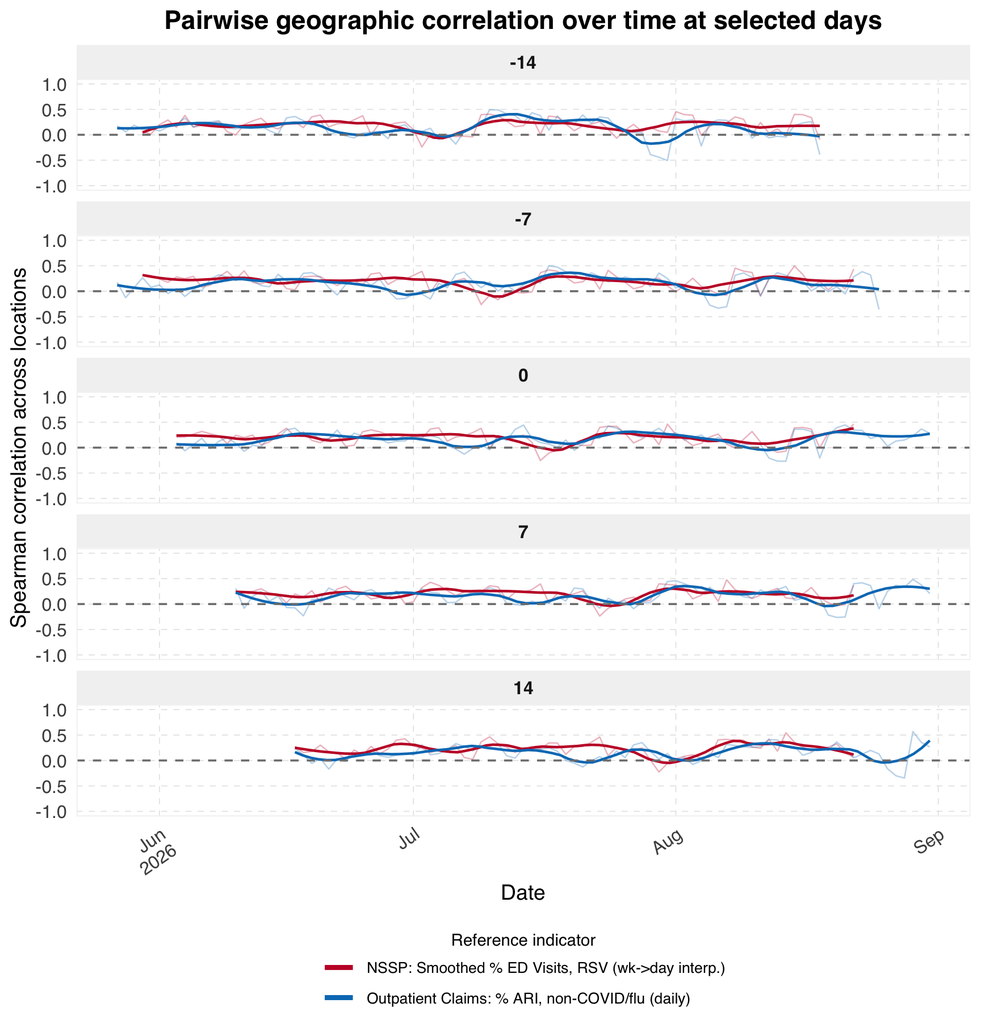

### 2.4 Geographic Heterogeneity at Optimal Lag

Maps and tables show location-level temporal agreement at the reference-specific optimal lag.

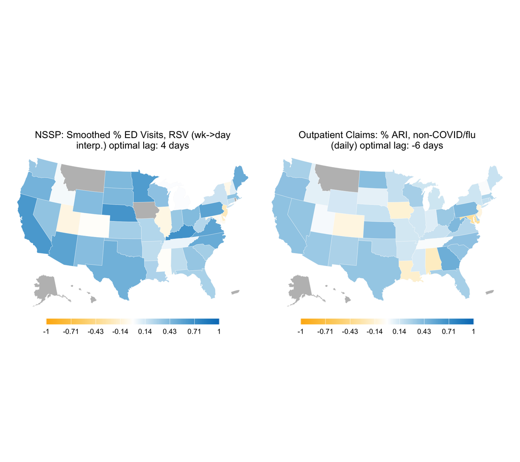

| Reference | Geo value | Geo name | Optimal lag | Spearman correlation | Rank |
| --- | --- | --- | --- | --- | --- |
| NSSP: Smoothed % ED Visits, RSV (wk-&gt;day interp.) | ky | Kentucky | 4 | 0.688858750062088 | 1 |
| NSSP: Smoothed % ED Visits, RSV (wk-&gt;day interp.) | ne | Nebraska | 4 | 0.6680037125272306 | 2 |
| NSSP: Smoothed % ED Visits, RSV (wk-&gt;day interp.) | ca | California | 4 | 0.6453917806121229 | 3 |
| NSSP: Smoothed % ED Visits, RSV (wk-&gt;day interp.) | mn | Minnesota | 4 | 0.6200145014775162 | 4 |
| NSSP: Smoothed % ED Visits, RSV (wk-&gt;day interp.) | pa | Pennsylvania | 4 | 0.5791826236089125 | 5 |
| NSSP: Smoothed % ED Visits, RSV (wk-&gt;day interp.) | az | Arizona | 4 | 0.5745870992291698 | 6 |
| NSSP: Smoothed % ED Visits, RSV (wk-&gt;day interp.) | va | Virginia | 4 | 0.5642898297112767 | 7 |
| NSSP: Smoothed % ED Visits, RSV (wk-&gt;day interp.) | nc | North Carolina | 4 | 0.5220591332846576 | 8 |
| NSSP: Smoothed % ED Visits, RSV (wk-&gt;day interp.) | me | Maine | 4 | 0.5163912973026445 | 9 |
| NSSP: Smoothed % ED Visits, RSV (wk-&gt;day interp.) | tx | Texas | 4 | 0.4918220511581365 | 10 |

[output cut: 88 more lines]

#### 2.4.1 Locations With Minimum Temporal Agreement

Locations with minimum temporal correlation at each reference-specific optimal lag.

Locations with minimum temporal agreement for each candidate/reference pair at the reference-specific optimal lag.

| Reference | Geo value | Geo name | Optimal lag | Temporal Spearman correlation |
| --- | --- | --- | --- | --- |
| NSSP: Smoothed % ED Visits, RSV (wk->day interp.) | dc | District of Columbia | 4 | -0.390 |
| NSSP: Smoothed % ED Visits, RSV (wk->day interp.) | nj | New Jersey | 4 | -0.231 |
| NSSP: Smoothed % ED Visits, RSV (wk->day interp.) | de | Delaware | 4 | -0.191 |
| NSSP: Smoothed % ED Visits, RSV (wk->day interp.) | ut | Utah | 4 | -0.097 |
| NSSP: Smoothed % ED Visits, RSV (wk->day interp.) | il | Illinois | 4 | -0.092 |
| Outpatient Claims: % ARI, non-COVID/flu (daily) | md | Maryland | -6 | -0.361 |
| Outpatient Claims: % ARI, non-COVID/flu (daily) | dc | District of Columbia | -6 | -0.336 |
| Outpatient Claims: % ARI, non-COVID/flu (daily) | al | Alabama | -6 | -0.214 |
| Outpatient Claims: % ARI, non-COVID/flu (daily) | la | Louisiana | -6 | -0.173 |
| Outpatient Claims: % ARI, non-COVID/flu (daily) | ia | Iowa | -6 | -0.147 |

### 2.5 Reference Agreement Check

Context check: agreement among the selected reference indicators.

For references $j$ and $k$, date-specific spatial agreement is

$$s^{(j,k)}_{\text{ref},t}
= \operatorname{cor}_S
\left(
\{R^{(j)}_{g,t}\}_{g},
\{R^{(k)}_{g,t}\}_{g}
\right).$$

The heatmap shows the mean of $s^{(j,k)}_{\text{ref},t}$ across dates.

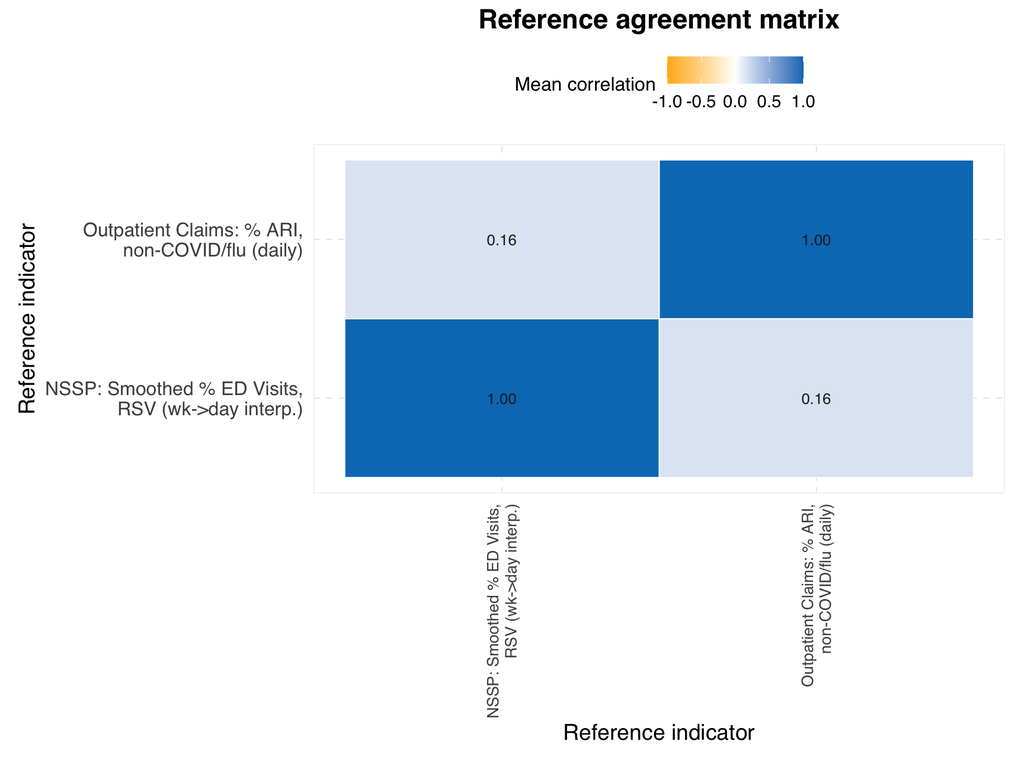

## 3 Summary

Main pairwise metrics. References are not combined.

Multi-reference pairwise metrics

| Reference | Mean geographic correlation | Median geographic correlation | Mean temporal correlation | Median temporal correlation | % locations \|correlation\| > 0.5 | Optimal lag | Mean correlation at optimal lag | Median correlation at optimal lag |
| --- | --- | --- | --- | --- | --- | --- | --- | --- |
| NSSP: Smoothed % ED Visits, RSV (wk->day interp.) | 0.194 | 0.211 | 0.259 | 0.301 | 19% | 4 | 0.271 | 0.321 |
| Outpatient Claims: % ARI, non-COVID/flu (daily) | 0.162 | 0.178 | 0.137 | 0.164 | 2% | -6 | 0.171 | 0.184 |